# Risk Factor Analysis

## Outcome Variable

**Outcome Variable:** sstunted

## Predictor Variables

**Intervention Variable:** impsan

**Adjustment Set:**

- arm
- sex
- W_mage
- meducyrs
- feducyrs
- hhwealth_quart
- hfoodsec
- W_mhtcm
- W_mwtkg
- W_mbmi
- W_nrooms
- W_nchldlt5
- W_parity
- impfloor
- safeh20
- delta_W_mage
- delta_meducyrs
- delta_feducyrs
- delta_hhwealth_quart
- delta_hfoodsec
- delta_W_mhtcm
- delta_W_mwtkg
- delta_W_mbmi
- delta_W_nrooms
- delta_W_nchldlt5
- delta_W_parity
- delta_impfloor
- delta_safeh20

## Stratifying Variables

The analysis was stratified on these variable(s):

- agecat
- studyid
- country

## Data Summary

| agecat | studyid | country | impsan | sstunted | n_cell | n |
| --- | --- | --- | --- | --- | --- | --- |
| Birth | COHORTS | GUATEMALA | 1 | 0 | 45 | 491 |
| Birth | COHORTS | GUATEMALA | 1 | 1 | 0 | 491 |
| Birth | COHORTS | GUATEMALA | 0 | 0 | 440 | 491 |
| Birth | COHORTS | GUATEMALA | 0 | 1 | 6 | 491 |
| Birth | COHORTS | INDIA | 1 | 0 | 1723 | 4776 |
| Birth | COHORTS | INDIA | 1 | 1 | 44 | 4776 |
| Birth | COHORTS | INDIA | 0 | 0 | 2912 | 4776 |
| Birth | COHORTS | INDIA | 0 | 1 | 97 | 4776 |
| Birth | COHORTS | PHILIPPINES | 1 | 0 | 178 | 1191 |
| Birth | COHORTS | PHILIPPINES | 1 | 1 | 0 | 1191 |
| Birth | COHORTS | PHILIPPINES | 0 | 0 | 994 | 1191 |
| Birth | COHORTS | PHILIPPINES | 0 | 1 | 19 | 1191 |
| Birth | CONTENT | PERU | 1 | 0 | 1 | 2 |
| Birth | CONTENT | PERU | 1 | 1 | 0 | 2 |
| Birth | CONTENT | PERU | 0 | 0 | 1 | 2 |
| Birth | CONTENT | PERU | 0 | 1 | 0 | 2 |
| Birth | JiVitA-3 | BANGLADESH | 1 | 0 | 13709 | 22431 |
| Birth | JiVitA-3 | BANGLADESH | 1 | 1 | 1511 | 22431 |
| Birth | JiVitA-3 | BANGLADESH | 0 | 0 | 6274 | 22431 |
| Birth | JiVitA-3 | BANGLADESH | 0 | 1 | 937 | 22431 |
| Birth | JiVitA-4 | BANGLADESH | 1 | 0 | 2012 | 2820 |
| Birth | JiVitA-4 | BANGLADESH | 1 | 1 | 169 | 2820 |
| Birth | JiVitA-4 | BANGLADESH | 0 | 0 | 575 | 2820 |
| Birth | JiVitA-4 | BANGLADESH | 0 | 1 | 64 | 2820 |
| Birth | MAL-ED | BANGLADESH | 1 | 0 | 174 | 213 |
| Birth | MAL-ED | BANGLADESH | 1 | 1 | 5 | 213 |
| Birth | MAL-ED | BANGLADESH | 0 | 0 | 33 | 213 |
| Birth | MAL-ED | BANGLADESH | 0 | 1 | 1 | 213 |
| Birth | MAL-ED | BRAZIL | 1 | 0 | 56 | 60 |
| Birth | MAL-ED | BRAZIL | 1 | 1 | 3 | 60 |

[output cut: 170 more lines]

The following strata were considered:

- agecat: 24 months, studyid: COHORTS, country: GUATEMALA
- agecat: 24 months, studyid: COHORTS, country: INDIA
- agecat: 24 months, studyid: COHORTS, country: PHILIPPINES
- agecat: 24 months, studyid: CONTENT, country: PERU
- agecat: 24 months, studyid: JiVitA-3, country: BANGLADESH
- agecat: 24 months, studyid: JiVitA-4, country: BANGLADESH
- agecat: 24 months, studyid: LCNI-5, country: MALAWI
- agecat: 24 months, studyid: MAL-ED, country: BANGLADESH
- agecat: 24 months, studyid: MAL-ED, country: BRAZIL
- agecat: 24 months, studyid: MAL-ED, country: INDIA
- agecat: 24 months, studyid: MAL-ED, country: NEPAL
- agecat: 24 months, studyid: MAL-ED, country: PERU
- agecat: 24 months, studyid: MAL-ED, country: SOUTH AFRICA
- agecat: 24 months, studyid: MAL-ED, country: TANZANIA, UNITED REPUBLIC OF
- agecat: 24 months, studyid: NIH-Birth, country: BANGLADESH
- agecat: 24 months, studyid: NIH-Crypto, country: BANGLADESH
- agecat: 24 months, studyid: PROVIDE, country: BANGLADESH
- agecat: 6 months, studyid: COHORTS, country: GUATEMALA
- agecat: 6 months, studyid: COHORTS, country: INDIA
- agecat: 6 months, studyid: COHORTS, country: PHILIPPINES
- agecat: 6 months, studyid: CONTENT, country: PERU
- agecat: 6 months, studyid: JiVitA-3, country: BANGLADESH
- agecat: 6 months, studyid: JiVitA-4, country: BANGLADESH
- agecat: 6 months, studyid: LCNI-5, country: MALAWI
- agecat: 6 months, studyid: MAL-ED, country: BANGLADESH
- agecat: 6 months, studyid: MAL-ED, country: BRAZIL
- agecat: 6 months, studyid: MAL-ED, country: INDIA
- agecat: 6 months, studyid: MAL-ED, country: NEPAL
- agecat: 6 months, studyid: MAL-ED, country: PERU
- agecat: 6 months, studyid: MAL-ED, country: SOUTH AFRICA
- agecat: 6 months, studyid: MAL-ED, country: TANZANIA, UNITED REPUBLIC OF
- agecat: 6 months, studyid: NIH-Birth, country: BANGLADESH
- agecat: 6 months, studyid: NIH-Crypto, country: BANGLADESH
- agecat: 6 months, studyid: PROVIDE, country: BANGLADESH
- agecat: Birth, studyid: COHORTS, country: GUATEMALA
- agecat: Birth, studyid: COHORTS, country: INDIA
- agecat: Birth, studyid: COHORTS, country: PHILIPPINES
- agecat: Birth, studyid: CONTENT, country: PERU
- agecat: Birth, studyid: JiVitA-3, country: BANGLADESH
- agecat: Birth, studyid: JiVitA-4, country: BANGLADESH
- agecat: Birth, studyid: MAL-ED, country: BANGLADESH
- agecat: Birth, studyid: MAL-ED, country: BRAZIL
- agecat: Birth, studyid: MAL-ED, country: INDIA
- agecat: Birth, studyid: MAL-ED, country: NEPAL
- agecat: Birth, studyid: MAL-ED, country: PERU
- agecat: Birth, studyid: MAL-ED, country: SOUTH AFRICA
- agecat: Birth, studyid: MAL-ED, country: TANZANIA, UNITED REPUBLIC OF
- agecat: Birth, studyid: NIH-Birth, country: BANGLADESH
- agecat: Birth, studyid: NIH-Crypto, country: BANGLADESH
- agecat: Birth, studyid: PROVIDE, country: BANGLADESH

### Dropped Strata

Some strata were dropped due to rare outcomes:

- agecat: Birth, studyid: COHORTS, country: GUATEMALA
- agecat: Birth, studyid: COHORTS, country: PHILIPPINES
- agecat: Birth, studyid: CONTENT, country: PERU
- agecat: Birth, studyid: MAL-ED, country: BANGLADESH
- agecat: Birth, studyid: MAL-ED, country: BRAZIL
- agecat: Birth, studyid: MAL-ED, country: INDIA
- agecat: Birth, studyid: MAL-ED, country: NEPAL
- agecat: Birth, studyid: MAL-ED, country: PERU
- agecat: Birth, studyid: MAL-ED, country: SOUTH AFRICA
- agecat: Birth, studyid: MAL-ED, country: TANZANIA, UNITED REPUBLIC OF
- agecat: Birth, studyid: NIH-Crypto, country: BANGLADESH
- agecat: Birth, studyid: PROVIDE, country: BANGLADESH
- agecat: 6 months, studyid: COHORTS, country: GUATEMALA
- agecat: 6 months, studyid: COHORTS, country: PHILIPPINES
- agecat: 6 months, studyid: CONTENT, country: PERU
- agecat: 6 months, studyid: LCNI-5, country: MALAWI
- agecat: 6 months, studyid: MAL-ED, country: BANGLADESH
- agecat: 6 months, studyid: MAL-ED, country: BRAZIL
- agecat: 6 months, studyid: MAL-ED, country: INDIA
- agecat: 6 months, studyid: MAL-ED, country: NEPAL
- agecat: 6 months, studyid: MAL-ED, country: PERU
- agecat: 6 months, studyid: MAL-ED, country: SOUTH AFRICA
- agecat: 6 months, studyid: MAL-ED, country: TANZANIA, UNITED REPUBLIC OF
- agecat: 6 months, studyid: PROVIDE, country: BANGLADESH
- agecat: 24 months, studyid: CONTENT, country: PERU
- agecat: 24 months, studyid: LCNI-5, country: MALAWI
- agecat: 24 months, studyid: MAL-ED, country: BANGLADESH
- agecat: 24 months, studyid: MAL-ED, country: BRAZIL
- agecat: 24 months, studyid: MAL-ED, country: NEPAL
- agecat: 24 months, studyid: MAL-ED, country: PERU
- agecat: 24 months, studyid: MAL-ED, country: SOUTH AFRICA
- agecat: 24 months, studyid: MAL-ED, country: TANZANIA, UNITED REPUBLIC OF
- agecat: 24 months, studyid: PROVIDE, country: BANGLADESH

## Methods Detail

We’re interested in the causal parameters $E[Y_a]$ for all values of $a \in \mathcal{A}$. These parameters represent the mean outcome if, possibly contrary to fact, we intervened to set all units to have $A=a$. Under the randomization and positivity assumptions, these are identified by the statistical parameters $\psi_a=E_W[E_{Y|A,W}(Y|A=a,W)]$. In addition, we’re interested in the mean of $Y$, $E[Y]$ under no intervention (the observed mean). We will estimate these parameters by using SuperLearner to fit the relevant likelihood factors – $E_{Y|A,W}(Y|A=a,W)$ and $p(A=a|W)$, and then updating our likelihood fit using a joint TMLE.

For unadjusted analyses ($W=\{\}$), initial likelihoods were estimated using Lrnr_glm to estimate the simple $E(Y|A)$ and Lrnr_mean to estimate $p(A)$. For adjusted analyses, a small library containing Lrnr_glmnet, Lrnr_xgboost, and Lrnr_mean was used.

Having estimated these parameters, we will then use the delta method to estimate relative risks and attributable risks relative to a prespecified baseline level of $A$.

# Results Detail

## Results Plots

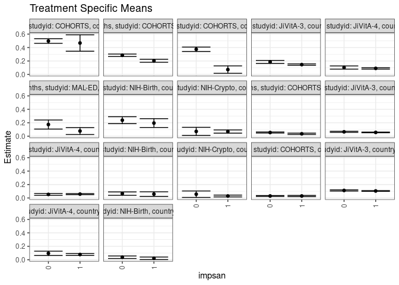

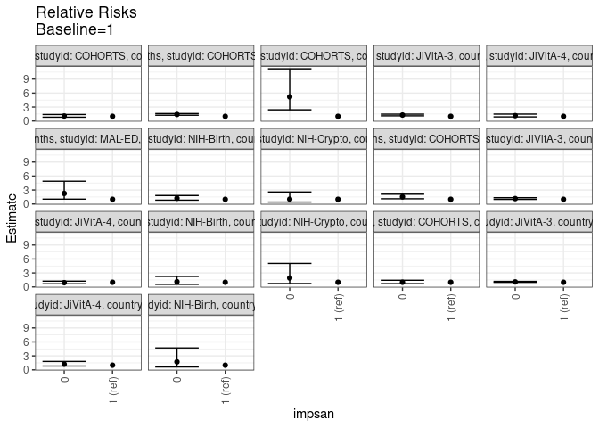

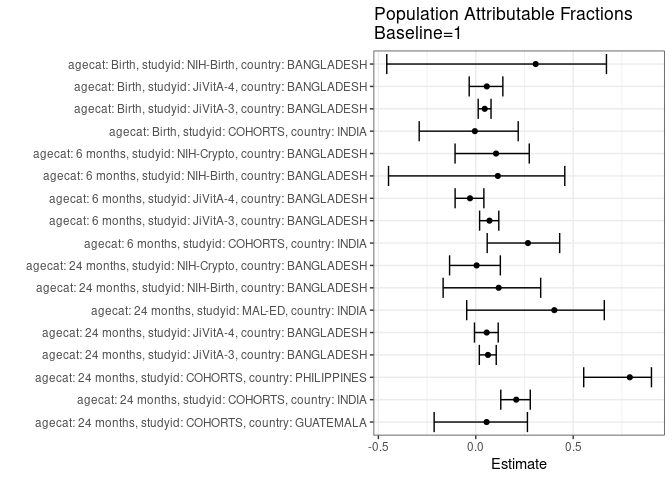

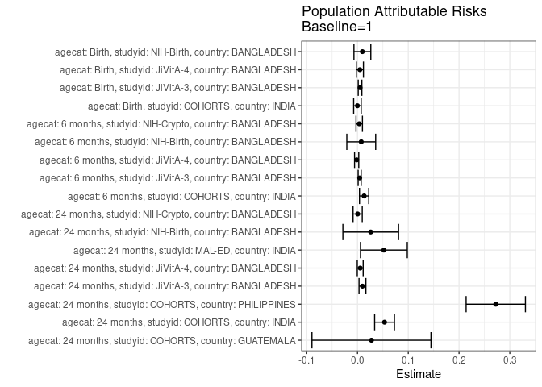

## Results Table

### Parameter: TSM

| agecat | studyid | country | intervention_level | baseline_level | estimate | ci_lower | ci_upper |
| --- | --- | --- | --- | --- | --- | --- | --- |
| Birth | COHORTS | INDIA | 1 | NA | 0.0296616 | 0.0208842 | 0.0384391 |
| Birth | COHORTS | INDIA | 0 | NA | 0.0296721 | 0.0236933 | 0.0356509 |
| Birth | JiVitA-3 | BANGLADESH | 1 | NA | 0.1041234 | 0.0984162 | 0.1098307 |
| Birth | JiVitA-3 | BANGLADESH | 0 | NA | 0.1120795 | 0.1028863 | 0.1212727 |
| Birth | JiVitA-4 | BANGLADESH | 1 | NA | 0.0779516 | 0.0635306 | 0.0923725 |
| Birth | JiVitA-4 | BANGLADESH | 0 | NA | 0.0953356 | 0.0631058 | 0.1275653 |
| Birth | NIH-Birth | BANGLADESH | 1 | NA | 0.0216450 | 0.0028637 | 0.0404264 |
| Birth | NIH-Birth | BANGLADESH | 0 | NA | 0.0371353 | 0.0180319 | 0.0562387 |
| 6 months | COHORTS | INDIA | 1 | NA | 0.0356427 | 0.0256856 | 0.0455999 |
| 6 months | COHORTS | INDIA | 0 | NA | 0.0545293 | 0.0467226 | 0.0623361 |
| 6 months | JiVitA-3 | BANGLADESH | 1 | NA | 0.0563972 | 0.0516689 | 0.0611254 |
| 6 months | JiVitA-3 | BANGLADESH | 0 | NA | 0.0650303 | 0.0566468 | 0.0734139 |
| 6 months | JiVitA-4 | BANGLADESH | 1 | NA | 0.0578299 | 0.0497940 | 0.0658657 |
| 6 months | JiVitA-4 | BANGLADESH | 0 | NA | 0.0530735 | 0.0390382 | 0.0671089 |
| 6 months | NIH-Birth | BANGLADESH | 1 | NA | 0.0577988 | 0.0238947 | 0.0917028 |
| 6 months | NIH-Birth | BANGLADESH | 0 | NA | 0.0645974 | 0.0394085 | 0.0897863 |
| 6 months | NIH-Crypto | BANGLADESH | 1 | NA | 0.0292683 | 0.0159371 | 0.0425994 |
| 6 months | NIH-Crypto | BANGLADESH | 0 | NA | 0.0561798 | 0.0083061 | 0.1040534 |
| 24 months | COHORTS | GUATEMALA | 1 | NA | 0.4674572 | 0.3452796 | 0.5896348 |
| 24 months | COHORTS | GUATEMALA | 0 | NA | 0.4966224 | 0.4623365 | 0.5309082 |
| 24 months | COHORTS | INDIA | 1 | NA | 0.2032159 | 0.1806084 | 0.2258234 |
| 24 months | COHORTS | INDIA | 0 | NA | 0.2849691 | 0.2667949 | 0.3031434 |
| 24 months | COHORTS | PHILIPPINES | 1 | NA | 0.0721042 | 0.0169505 | 0.1272579 |
| 24 months | COHORTS | PHILIPPINES | 0 | NA | 0.3743384 | 0.3417825 | 0.4068942 |
| 24 months | JiVitA-3 | BANGLADESH | 1 | NA | 0.1462301 | 0.1354219 | 0.1570382 |
| 24 months | JiVitA-3 | BANGLADESH | 0 | NA | 0.1862103 | 0.1638393 | 0.2085814 |
| 24 months | JiVitA-4 | BANGLADESH | 1 | NA | 0.0898708 | 0.0791066 | 0.1006349 |
| 24 months | JiVitA-4 | BANGLADESH | 0 | NA | 0.1026983 | 0.0789250 | 0.1264717 |
| 24 months | MAL-ED | INDIA | 1 | NA | 0.0769231 | 0.0255961 | 0.1282501 |
| 24 months | MAL-ED | INDIA | 0 | NA | 0.1735537 | 0.1059225 | 0.2411849 |
| 24 months | NIH-Birth | BANGLADESH | 1 | NA | 0.1954085 | 0.1299547 | 0.2608623 |
| 24 months | NIH-Birth | BANGLADESH | 0 | NA | 0.2385006 | 0.1865798 | 0.2904214 |
| 24 months | NIH-Crypto | BANGLADESH | 1 | NA | 0.0692841 | 0.0453420 | 0.0932261 |
| 24 months | NIH-Crypto | BANGLADESH | 0 | NA | 0.0714286 | 0.0110372 | 0.1318199 |

### Parameter: E(Y)

| agecat | studyid | country | intervention_level | baseline_level | estimate | ci_lower | ci_upper |
| --- | --- | --- | --- | --- | --- | --- | --- |
| Birth | COHORTS | INDIA | NA | NA | 0.0295226 | 0.0247216 | 0.0343236 |
| Birth | JiVitA-3 | BANGLADESH | NA | NA | 0.1091347 | 0.1045758 | 0.1136935 |
| Birth | JiVitA-4 | BANGLADESH | NA | NA | 0.0826241 | 0.0709364 | 0.0943118 |
| Birth | NIH-Birth | BANGLADESH | NA | NA | 0.0312500 | 0.0174085 | 0.0450915 |
| 6 months | COHORTS | INDIA | NA | NA | 0.0486824 | 0.0426994 | 0.0546654 |
| 6 months | JiVitA-3 | BANGLADESH | NA | NA | 0.0606548 | 0.0567999 | 0.0645096 |
| 6 months | JiVitA-4 | BANGLADESH | NA | NA | 0.0561658 | 0.0493946 | 0.0629370 |
| 6 months | NIH-Birth | BANGLADESH | NA | NA | 0.0651769 | 0.0442802 | 0.0860736 |
| 6 months | NIH-Crypto | BANGLADESH | NA | NA | 0.0326705 | 0.0195292 | 0.0458117 |
| 24 months | COHORTS | GUATEMALA | NA | NA | 0.4949608 | 0.4621502 | 0.5277714 |
| 24 months | COHORTS | INDIA | NA | NA | 0.2564649 | 0.2424885 | 0.2704414 |
| 24 months | COHORTS | PHILIPPINES | NA | NA | 0.3444444 | 0.3148293 | 0.3740596 |
| 24 months | JiVitA-3 | BANGLADESH | NA | NA | 0.1559963 | 0.1472522 | 0.1647404 |
| 24 months | JiVitA-4 | BANGLADESH | NA | NA | 0.0952180 | 0.0856733 | 0.1047628 |
| 24 months | MAL-ED | INDIA | NA | NA | 0.1288889 | 0.0850087 | 0.1727691 |
| 24 months | NIH-Birth | BANGLADESH | NA | NA | 0.2214452 | 0.1821080 | 0.2607825 |
| 24 months | NIH-Crypto | BANGLADESH | NA | NA | 0.0695825 | 0.0473246 | 0.0918405 |

### Parameter: RR

| agecat | studyid | country | intervention_level | baseline_level | estimate | ci_lower | ci_upper |
| --- | --- | --- | --- | --- | --- | --- | --- |
| Birth | COHORTS | INDIA | 1 | 1 | 1.0000000 | 1.0000000 | 1.000000 |
| Birth | COHORTS | INDIA | 0 | 1 | 1.0003530 | 0.6994013 | 1.430804 |
| Birth | JiVitA-3 | BANGLADESH | 1 | 1 | 1.0000000 | 1.0000000 | 1.000000 |
| Birth | JiVitA-3 | BANGLADESH | 0 | 1 | 1.0764099 | 0.9805781 | 1.181607 |
| Birth | JiVitA-4 | BANGLADESH | 1 | 1 | 1.0000000 | 1.0000000 | 1.000000 |
| Birth | JiVitA-4 | BANGLADESH | 0 | 1 | 1.2230098 | 0.8285729 | 1.805216 |
| Birth | NIH-Birth | BANGLADESH | 1 | 1 | 1.0000000 | 1.0000000 | 1.000000 |
| Birth | NIH-Birth | BANGLADESH | 0 | 1 | 1.7156499 | 0.6256664 | 4.704511 |
| 6 months | COHORTS | INDIA | 1 | 1 | 1.0000000 | 1.0000000 | 1.000000 |
| 6 months | COHORTS | INDIA | 0 | 1 | 1.5298856 | 1.1185961 | 2.092400 |
| 6 months | JiVitA-3 | BANGLADESH | 1 | 1 | 1.0000000 | 1.0000000 | 1.000000 |
| 6 months | JiVitA-3 | BANGLADESH | 0 | 1 | 1.1530780 | 0.9916209 | 1.340824 |
| 6 months | JiVitA-4 | BANGLADESH | 1 | 1 | 1.0000000 | 1.0000000 | 1.000000 |
| 6 months | JiVitA-4 | BANGLADESH | 0 | 1 | 0.9177533 | 0.6805318 | 1.237666 |
| 6 months | NIH-Birth | BANGLADESH | 1 | 1 | 1.0000000 | 1.0000000 | 1.000000 |
| 6 months | NIH-Birth | BANGLADESH | 0 | 1 | 1.1176252 | 0.5534126 | 2.257061 |
| 6 months | NIH-Crypto | BANGLADESH | 1 | 1 | 1.0000000 | 1.0000000 | 1.000000 |
| 6 months | NIH-Crypto | BANGLADESH | 0 | 1 | 1.9194757 | 0.7303803 | 5.044477 |
| 24 months | COHORTS | GUATEMALA | 1 | 1 | 1.0000000 | 1.0000000 | 1.000000 |
| 24 months | COHORTS | GUATEMALA | 0 | 1 | 1.0623911 | 0.8113802 | 1.391055 |
| 24 months | COHORTS | INDIA | 1 | 1 | 1.0000000 | 1.0000000 | 1.000000 |
| 24 months | COHORTS | INDIA | 0 | 1 | 1.4022977 | 1.2374064 | 1.589162 |
| 24 months | COHORTS | PHILIPPINES | 1 | 1 | 1.0000000 | 1.0000000 | 1.000000 |
| 24 months | COHORTS | PHILIPPINES | 0 | 1 | 5.1916308 | 2.4034384 | 11.214363 |
| 24 months | JiVitA-3 | BANGLADESH | 1 | 1 | 1.0000000 | 1.0000000 | 1.000000 |
| 24 months | JiVitA-3 | BANGLADESH | 0 | 1 | 1.2734064 | 1.1077395 | 1.463849 |
| 24 months | JiVitA-4 | BANGLADESH | 1 | 1 | 1.0000000 | 1.0000000 | 1.000000 |
| 24 months | JiVitA-4 | BANGLADESH | 0 | 1 | 1.1427334 | 0.8835407 | 1.477962 |
| 24 months | MAL-ED | INDIA | 1 | 1 | 1.0000000 | 1.0000000 | 1.000000 |
| 24 months | MAL-ED | INDIA | 0 | 1 | 2.2561983 | 1.0418240 | 4.886076 |
| 24 months | NIH-Birth | BANGLADESH | 1 | 1 | 1.0000000 | 1.0000000 | 1.000000 |
| 24 months | NIH-Birth | BANGLADESH | 0 | 1 | 1.2205229 | 0.8218411 | 1.812608 |
| 24 months | NIH-Crypto | BANGLADESH | 1 | 1 | 1.0000000 | 1.0000000 | 1.000000 |
| 24 months | NIH-Crypto | BANGLADESH | 0 | 1 | 1.0309524 | 0.4135862 | 2.569870 |

### Parameter: PAR

| agecat | studyid | country | intervention_level | baseline_level | estimate | ci_lower | ci_upper |
| --- | --- | --- | --- | --- | --- | --- | --- |
| Birth | COHORTS | INDIA | 1 | NA | -0.0001390 | -0.0075634 | 0.0072853 |
| Birth | JiVitA-3 | BANGLADESH | 1 | NA | 0.0050112 | 0.0014195 | 0.0086030 |
| Birth | JiVitA-4 | BANGLADESH | 1 | NA | 0.0046725 | -0.0023341 | 0.0116791 |
| Birth | NIH-Birth | BANGLADESH | 1 | NA | 0.0096050 | -0.0070171 | 0.0262270 |
| 6 months | COHORTS | INDIA | 1 | NA | 0.0130396 | 0.0039289 | 0.0221504 |
| 6 months | JiVitA-3 | BANGLADESH | 1 | NA | 0.0042576 | 0.0012653 | 0.0072499 |
| 6 months | JiVitA-4 | BANGLADESH | 1 | NA | -0.0016641 | -0.0058076 | 0.0024795 |
| 6 months | NIH-Birth | BANGLADESH | 1 | NA | 0.0073781 | -0.0210480 | 0.0358043 |
| 6 months | NIH-Crypto | BANGLADESH | 1 | NA | 0.0034022 | -0.0029150 | 0.0097193 |
| 24 months | COHORTS | GUATEMALA | 1 | NA | 0.0275036 | -0.0897213 | 0.1447284 |
| 24 months | COHORTS | INDIA | 1 | NA | 0.0532491 | 0.0337430 | 0.0727551 |
| 24 months | COHORTS | PHILIPPINES | 1 | NA | 0.2723403 | 0.2139266 | 0.3307539 |
| 24 months | JiVitA-3 | BANGLADESH | 1 | NA | 0.0097662 | 0.0029927 | 0.0165397 |
| 24 months | JiVitA-4 | BANGLADESH | 1 | NA | 0.0053473 | -0.0004633 | 0.0111578 |
| 24 months | MAL-ED | INDIA | 1 | NA | 0.0519658 | 0.0058733 | 0.0980583 |
| 24 months | NIH-Birth | BANGLADESH | 1 | NA | 0.0260367 | -0.0287791 | 0.0808525 |
| 24 months | NIH-Crypto | BANGLADESH | 1 | NA | 0.0002984 | -0.0087425 | 0.0093394 |

### Parameter: PAF

| agecat | studyid | country | intervention_level | baseline_level | estimate | ci_lower | ci_upper |
| --- | --- | --- | --- | --- | --- | --- | --- |
| Birth | COHORTS | INDIA | 1 | NA | -0.0047089 | -0.2904784 | 0.2177785 |
| Birth | JiVitA-3 | BANGLADESH | 1 | NA | 0.0459180 | 0.0124421 | 0.0782590 |
| Birth | JiVitA-4 | BANGLADESH | 1 | NA | 0.0565516 | -0.0337676 | 0.1389796 |
| Birth | NIH-Birth | BANGLADESH | 1 | NA | 0.3073593 | -0.4568509 | 0.6706930 |
| 6 months | COHORTS | INDIA | 1 | NA | 0.2678510 | 0.0585609 | 0.4306141 |
| 6 months | JiVitA-3 | BANGLADESH | 1 | NA | 0.0701938 | 0.0196129 | 0.1181652 |
| 6 months | JiVitA-4 | BANGLADESH | 1 | NA | -0.0296276 | -0.1060953 | 0.0415537 |
| 6 months | NIH-Birth | BANGLADESH | 1 | NA | 0.1132015 | -0.4478715 | 0.4568498 |
| 6 months | NIH-Crypto | BANGLADESH | 1 | NA | 0.1041357 | -0.1063416 | 0.2745705 |
| 24 months | COHORTS | GUATEMALA | 1 | NA | 0.0555672 | -0.2137153 | 0.2651050 |
| 24 months | COHORTS | INDIA | 1 | NA | 0.2076271 | 0.1283536 | 0.2796909 |
| 24 months | COHORTS | PHILIPPINES | 1 | NA | 0.7906652 | 0.5540103 | 0.9017443 |
| 24 months | JiVitA-3 | BANGLADESH | 1 | NA | 0.0626054 | 0.0181862 | 0.1050150 |
| 24 months | JiVitA-4 | BANGLADESH | 1 | NA | 0.0561580 | -0.0066715 | 0.1150661 |
| 24 months | MAL-ED | INDIA | 1 | NA | 0.4031830 | -0.0465924 | 0.6596664 |
| 24 months | NIH-Birth | BANGLADESH | 1 | NA | 0.1175763 | -0.1676154 | 0.3331095 |
| 24 months | NIH-Crypto | BANGLADESH | 1 | NA | 0.0042890 | -0.1344942 | 0.1260948 |